# Design catalog

Standard benchmarks for untreated panel prediction and treatment-effect recovery.

These designs vary how untreated outcomes are generated while keeping the sample layout and treatment effects fixed. Use them to compare estimators under different forms of panel dependence.

## 1 Common structure

`CanonicalPanelConfig` defines the sample:

- 160 control and 40 treated units by default;
- 40 pre-treatment and 10 post-treatment periods;
- one treated cohort at the first post-treatment period;
- a linear post-treatment effect;
- Gaussian observation noise.

```python
import matplotlib.pyplot as plt
import numpy as np

from pypanelsim import designs

config = designs.CanonicalPanelConfig(
    n_control=160,
    n_treated=40,
    n_pre=40,
    n_post=10,
    effect_slope=0.2,
    noise_variance=0.36,
)

print(designs.available_canonical_designs())
```

```
('classic_factor', 'factor_synthetic', 'mixed_factor', 'synthetic_control', 'time_series', 'weak_factor')
```

All direct functions return a `PanelDataset`. Add `_design` to obtain a reusable `PanelSimulator`.

```python
panel = designs.classic_factor(overlap=1.0, config=config, seed=42)
simulator = designs.classic_factor_design(overlap=1.0, config=config)
print(panel.shape, simulator.name)
```

```
(200, 50) classic_factor
```

## 2 Select an untreated-outcome model

| Family | Untreated outcome structure | Main stress |
| --- | --- | --- |
| `classic_factor` | one strong latent factor | treated-control loading overlap |
| `weak_factor` | several weaker factors | diffuse low-rank signal |
| `synthetic_control` | treated loadings generated from sparse donor weights | donor sparsity |
| `factor_synthetic` | factor signal plus donor-weight relation | joint factor and sparse-synthetic structure |
| `time_series` | unit-specific stationary or integrated autoregression | temporal persistence |
| `mixed_factor` | different factor models across unit groups | heterogeneous outcome process |

Each family describes the generated untreated outcomes, not the estimator that must be used on them.

## 3 Factor overlap

In the factor designs, `overlap=0` gives treated and control units similar loading distributions. Larger values separate those distributions.

```python
overlap_panels = {
    value: designs.classic_factor(overlap=value, seed=110)
    for value in (0.0, 1.0)
}

for value, item in overlap_panels.items():
    outcome_metadata = item.metadata["outcome"]
    print(value, outcome_metadata["model"])
```

```
0.0 ClassicFactorOutcome
1.0 ClassicFactorOutcome
```

Metadata stores factor paths, loadings, donor weights, and innovations for direct inspection.

## 4 Synthetic-control sparsity

`active_share` is the share of controls with nonzero donor weights for each treated unit.

```python
sparse = designs.synthetic_control(active_share=0.1, seed=140)
dense = designs.synthetic_control(active_share=0.5, seed=140)

print(sparse.metadata["outcome"]["active_share"])
print(dense.metadata["outcome"]["active_share"])
```

```
0.1
0.5
```

This parameter changes untreated outcomes. It does not select or fit a synthetic-control estimator.

## 5 Temporal persistence

`time_series` supports stationary AR(1) paths and integrated ARIMA(1,1,0) paths. `coefficient` controls persistence.

```python
stationary = designs.time_series(
    coefficient=0.9,
    integrated=False,
    seed=150,
)
integrated = designs.time_series(
    coefficient=0.9,
    integrated=True,
    seed=150,
)

print(stationary.metadata["outcome"]["integrated"])
print(integrated.metadata["outcome"]["integrated"])
```

```
False
True
```

## 6 Change the sample, not the model

Pass one configuration to several constructors. This keeps sample dimensions, treatment timing, effects, and noise variance aligned.

```python
small = designs.CanonicalPanelConfig(
    n_control=60,
    n_treated=20,
    n_pre=24,
    n_post=8,
)

panels = {
    "classic": designs.classic_factor(config=small, seed=17),
    "weak": designs.weak_factor(config=small, seed=17),
    "time": designs.time_series(config=small, seed=17),
}

print({name: item.shape for name, item in panels.items()})
```

```
{'classic': (80, 32), 'weak': (80, 32), 'time': (80, 32)}
```

## 7 Use the dispatcher

Use a named dispatcher when design names come from a configuration file:

```python
simulator = designs.make_canonical(
    "time_series",
    coefficient=0.5,
    integrated=False,
    config=small,
)
print(simulator.simulate(seed=7).shape)
```

```
(80, 32)
```

Use the explicit constructor in ordinary Python code. It gives static tools and readers more information.

## 8 Visual catalog

Each row below compares two variants of one untreated-outcome family. Treatment timing and effects remain the same.

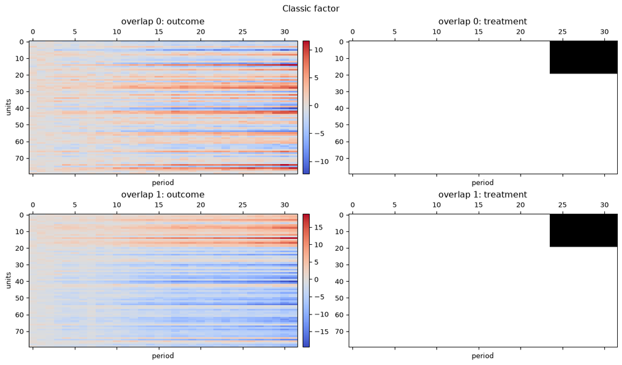

(a) Outcome and treatment matrices for the six canonical panel families.

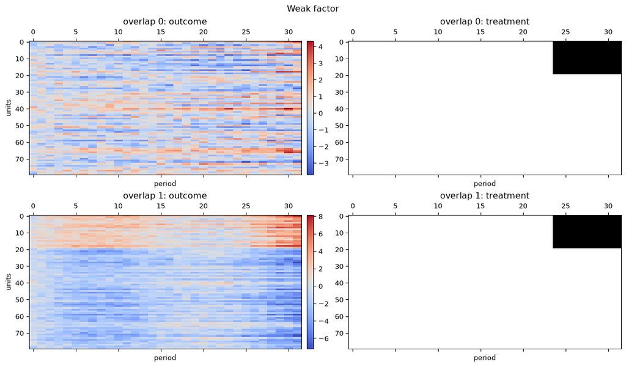

(b)

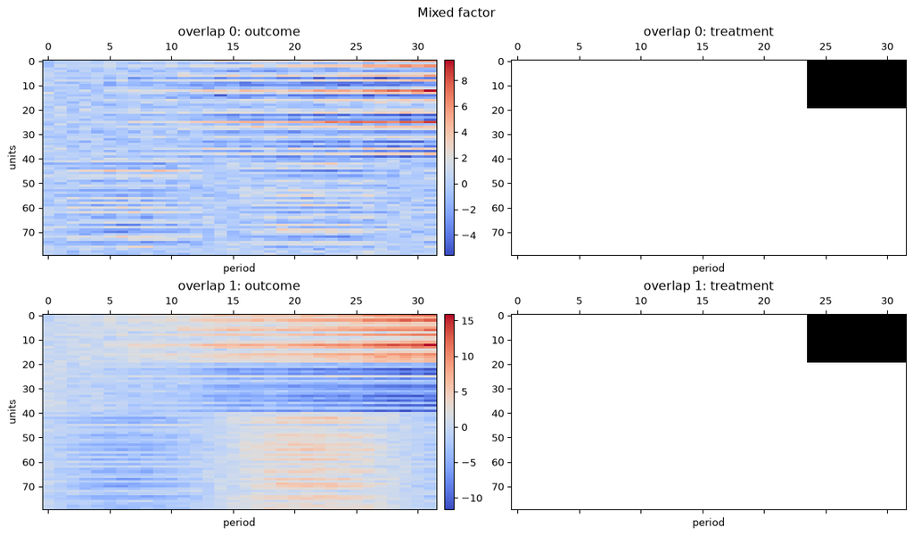

(c)

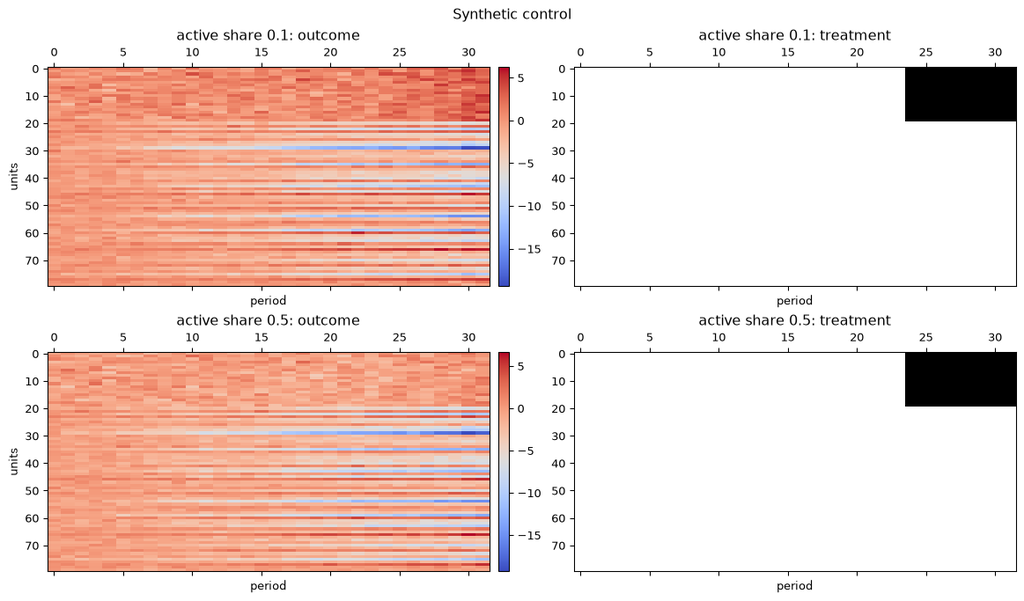

(d)

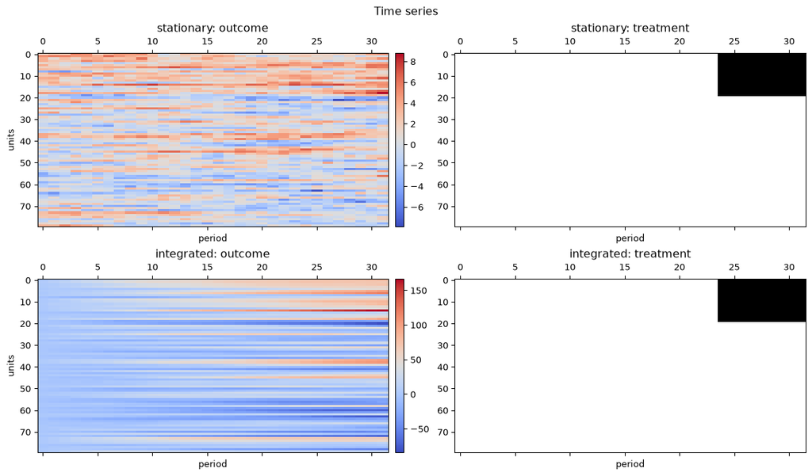

(e)

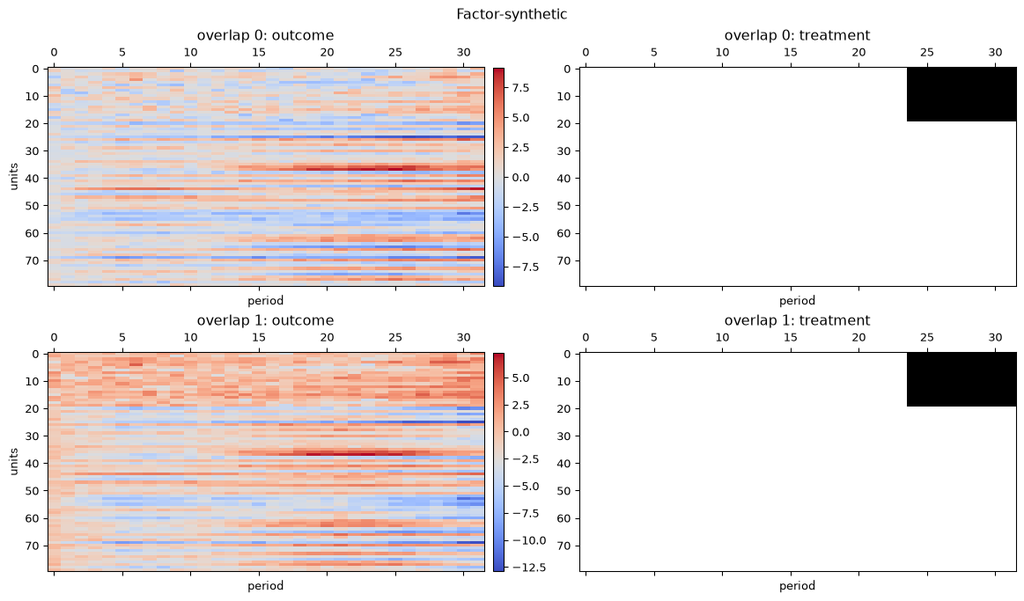

(f)

Figure 1

```python
visual_config = designs.CanonicalPanelConfig(
    n_control=60,
    n_treated=20,
    n_pre=24,
    n_post=8,
)
visual_cases = {
    "Classic factor": (
        ("overlap 0", designs.classic_factor(config=visual_config, overlap=0, seed=110)),
        ("overlap 1", designs.classic_factor(config=visual_config, overlap=1, seed=110)),
    ),
    "Weak factor": (
        ("overlap 0", designs.weak_factor(config=visual_config, overlap=0, seed=120)),
        ("overlap 1", designs.weak_factor(config=visual_config, overlap=1, seed=120)),
    ),
    "Mixed factor": (
        ("overlap 0", designs.mixed_factor(config=visual_config, overlap=0, seed=130)),
        ("overlap 1", designs.mixed_factor(config=visual_config, overlap=1, seed=130)),
    ),
    "Synthetic control": (
        ("active share 0.1", designs.synthetic_control(config=visual_config, active_share=0.1, seed=140)),
        ("active share 0.5", designs.synthetic_control(config=visual_config, active_share=0.5, seed=140)),
    ),
    "Time series": (
        ("stationary", designs.time_series(config=visual_config, coefficient=0.9, integrated=False, seed=150)),
        ("integrated", designs.time_series(config=visual_config, coefficient=0.9, integrated=True, seed=150)),
    ),
    "Factor-synthetic": (
        ("overlap 0", designs.factor_synthetic(config=visual_config, overlap=0, seed=160)),
        ("overlap 1", designs.factor_synthetic(config=visual_config, overlap=1, seed=160)),
    ),
}

for family, variants in visual_cases.items():
    figure, axes = plt.subplots(2, 2, figsize=(12, 7), constrained_layout=True)
    for row, (label, draw) in enumerate(variants):
        order = np.argsort(draw.adoption_times, kind="stable")
        outcome_image = axes[row, 0].matshow(
            draw.outcome[order],
            aspect="auto",
            cmap="coolwarm",
        )
        axes[row, 1].matshow(
            draw.treatment[order],
            aspect="auto",
            cmap="Greys",
            vmin=0.0,
            vmax=1.0,
        )
        axes[row, 0].set_title(f"{label}: outcome")
        axes[row, 1].set_title(f"{label}: treatment")
        axes[row, 0].set_ylabel("units")
        figure.colorbar(outcome_image, ax=axes[row, 0], fraction=0.025, pad=0.02)
        for axis in axes[row]:
            axis.set_xlabel("period")
    figure.suptitle(family)
    plt.show()
```

For dynamic cohort effects, conditional trends, or support-aware event studies, continue to Research designs.